# FordGoBike Data Visualization

## by Yash Motwani

## Investigation Overview

In this project, we will investigate and understand the relation of member's age group and gender with their bike usage in terms of duration, weekdays, months and hours.

## Dataset Overview

In this project we will explain Baywheels(FordGoBike) Trip Data. In the dataset, there are total 16 columns for referring to 16 different variables and 1,861,220 rows referring to observations. Following are the further details about variables:

1. 3 columns referring to 3 categorical variables.

   a. `member_gender` - with 3 categories - Male, Female, Other

   b. `bike_share_for_all_trip` - with 2 categories referring to member's interest - yes, no

   c. `user_type` - with 2 categories - customer, subscriber
1. 10 columns referring to postion, name, id, date and time of the starting and ending stations
1. 1 column for bike information(`bike_id`), 1 column for `member_birth_year` and 1 column for trip duration(`duration_sec`)

## Distribution of Bike Rents Among People of Different Age Groups and Genders

**Starting from individual distributions it can be seen that most number of times bike have been rented by adults, followed by youth and at the last the seniors. This may be due to the less activity of the seniors and the fact that the working class mostly includes adults.**

**With respect to genders, males have rented the bikes most of the times followed by females and other genders. Maybe people in the young age groups would have preferred the bikes always.**

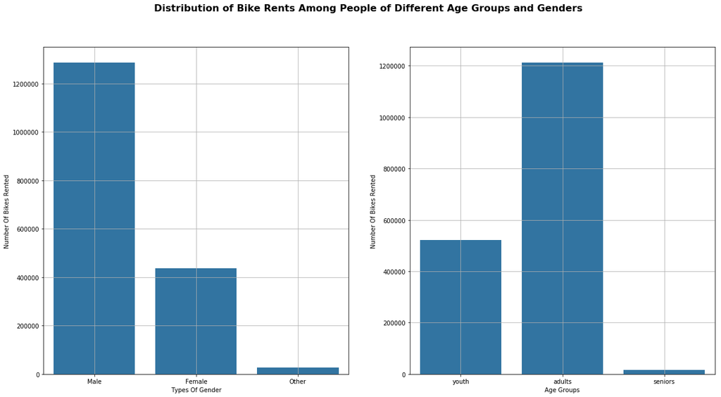

```python
base_color = sb.color_palette()[0]
yticks = np.linspace(0, 1200000, 100000)

# Create a subplot to plot the distributions of member_gender, user_type and bike_share_for_all_trip altogether
fig, axis = plt.subplots(ncols = 2, figsize = [20,10])
sb.countplot(data = ford_data_cl, x = 'member_gender', color = base_color, ax = axis[0])
plt.sca(axis[0])
plt.xlabel('Types Of Gender')
plt.ylabel('Number Of Bikes Rented')
plt.grid()
sb.countplot(data = ford_data_cl, x = 'age_group', color = base_color, ax = axis[1])
plt.sca(axis[1])
plt.xlabel('Age Groups')
plt.ylabel('Number Of Bikes Rented')
plt.grid()

plt.suptitle('Distribution of Bike Rents Among People of Different Age Groups and Genders', fontsize = 16, fontweight = 'bold');
```

## Distribution Of Number of Bike Rents by Weekdays for Each Age Group and Gender Type

**Now we are ready to explore the relationships between our time variables (weekday, month and hour) with variables for identifying user information(age group and gender). Let's start exploring relationship of weekdays with user information variables**

**Here, moving from left plots towards right, it's clearly depictable that :**

1. **On Tuesdays adults have been renting more bikes and on sundays the least. Same is the case with young people. We can't say anything clearly about seniors as the counts are too low to be able to depict anything.**
1. **The gender categories follow a similar trend as age groups with males following adults, females following the youth and others following the seniors**

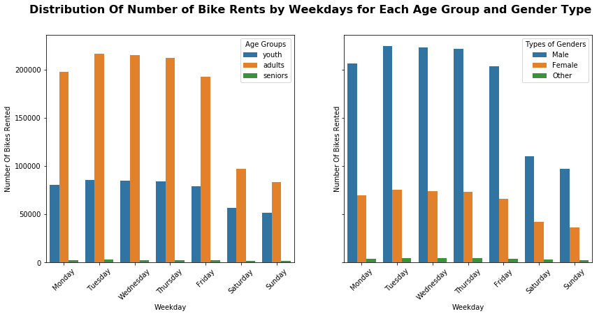

```python
# Plot the subplots and collect their outputs as figure and axis
figure, axis = plt.subplots(ncols = 2, sharey = True, figsize = (14, 6))

# Plot the relationships using axis variable and cat_count function in the subplots
cat_count('week_day', 'age_group', axis[0])
plt.sca(axis[0])
plt.xlabel('Weekday')
plt.ylabel('Number Of Bikes Rented')
plt.legend(title='Age Groups')




cat_count('week_day', 'member_gender', axis[1])
plt.sca(axis[1])
plt.xlabel('Weekday')
plt.ylabel('Number Of Bikes Rented')
plt.legend(title='Types of Genders')

plt.suptitle('Distribution Of Number of Bike Rents by Weekdays for Each Age Group and Gender Type', fontsize = 16, fontweight = 'bold');
```

## Distribution Of Number of Bike Rents by Months for Each Age Group and Gender Type

**Now, we will explore relationship of months with user information variables**

**Here, moving from left plots towards right, it can be clearly seen that :**

**1. In June, adults have rented most bikes and in January, the least. While youths have rented most bikes in October and again in January, they have also rented least bikes. We can't say anything clearly about seniors as the counts are too low to be able to depict anything.**

**2. The gender categories follow a somewhat similar to age groups and user types with females following the youth others following the seniors.**

**3. In general, adults and males have rented bikes mostly.**

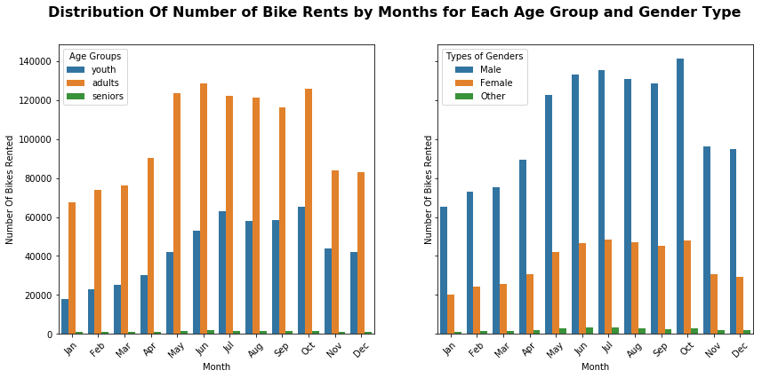

```python
figure, axis = plt.subplots(ncols = 2, sharey = True, figsize = (14, 6))

cat_count('month', 'age_group', axis[0])
plt.sca(axis[0])
plt.xlabel('Month')
plt.ylabel('Number Of Bikes Rented')
plt.legend(title='Age Groups')



cat_count('month', 'member_gender', axis[1])
plt.sca(axis[1])
plt.xlabel('Month')
plt.ylabel('Number Of Bikes Rented')
plt.legend(title='Types of Genders')

plt.suptitle('Distribution Of Number of Bike Rents by Months for Each Age Group and Gender Type', fontsize = 16, fontweight = 'bold');
```

## Distribution Of Number of Bike Rents by Hours for Each Age Group and Gender Type

**Now, we will explore relationship of hours with user information variables**

**Here, moving from left plots towards right, we can say that :**

**1. 8a.m. and 5 p.m. have been the most busy hours for adults to rent the bikes and 3 a.m. and 4 a.m., the least. Youths have also rented most and least bikes during the same hours as adults . We can't say anything clearly about seniors as the counts are too low to be able to depict anything.**

**2. The gender categories follow a somewhat similar to age groups with males following adults, females following the youth others following the seniors.**

**3. In general, adults and males have rented bikes mostly.**

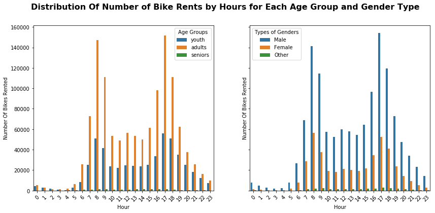

```python
figure, axis = plt.subplots(ncols = 2, sharey = True, figsize = (14, 6))

cat_count('hour', 'age_group', axis[0])
plt.sca(axis[0])
plt.xlabel('Hour')
plt.ylabel('Number Of Bikes Rented')
plt.legend(title='Age Groups')


cat_count('hour', 'member_gender', axis[1])
plt.sca(axis[1])
plt.xlabel('Hour')
plt.ylabel('Number Of Bikes Rented')
plt.legend(title='Types of Genders')

plt.suptitle('Distribution Of Number of Bike Rents by Hours for Each Age Group and Gender Type', fontsize = 16, fontweight = 'bold');
```

## Average Duration Comparison for Each Age Group and Gender Type Among Weekdays

**In duration vs weekdays pointplots and duration vs month pointplots, we can explore further with variables that identify user information, age group and gender specifically, as both these variables had shown similar trends when we related them with time variables hour, weekday and month. So let's start with `week_day` vs `duration_sec` pointplot from the previous section and explore it further with genders and age groups.**

**1. Almost all the three age groups show similar trend in terms of for what average duration they rented the bikes on each weekday. From monday to friday, all the 3 age groups rented the bikes for a low average duration with adults at the lowest and seniors mostly at the highest, while on weekends, all the 3 age groups rented the bikes for a high average duration with mostly youth at the highest and seniors at the lowest.**

**2. All the three genders differ a lot in terms of for what average duration they rented the bikes on each weekday. Males have always rented the bikes for a low average duration while females have always rented the bikes for a high average duration. On Tuesdays others and females have rented the bikes for almost the same average duration. On weekends, people are likely to rent bikes for a high duration.**

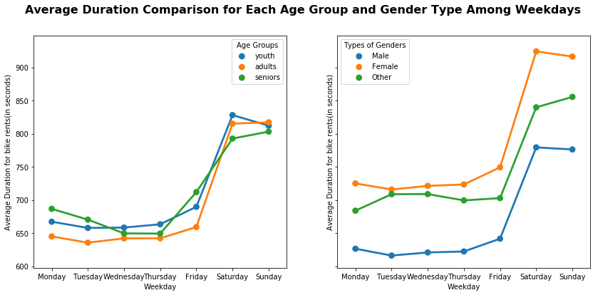

```python
# Plot the 2 multivariate plots side by side
figure, axis = plt.subplots(ncols = 2, sharey = True, figsize = (14, 6))

sb.pointplot(data = cat_time_data, x = 'week_day', y = 'duration_sec', hue = 'age_group', linestyles = '-', errwidth = 0, ax = axis[0])
plt.sca(axis[0])
plt.xlabel('Weekday')
plt.ylabel('Average Duration for bike rents(in seconds)')
plt.legend(title='Age Groups')


sb.pointplot(data = cat_time_data, x = 'week_day', y = 'duration_sec', hue = 'member_gender', linestyles = '-', errwidth = 0, ax = axis[1])
plt.sca(axis[1])
plt.xlabel('Weekday')
plt.ylabel('Average Duration for bike rents(in seconds)')
plt.legend(title='Types of Genders')

plt.suptitle('Average Duration Comparison for Each Age Group and Gender Type Among Weekdays', fontsize = 16, fontweight = 'bold');
```

## Average Duration Comparison for Each Age Group and Gender Type Among Months

**Now, let's explore `month` vs `duration_sec` pointplot further with genders and age groups**

**1. There is sufficient difference in trends among the 3 age groups and Seniors especially are showing much variation along the months in terms of for what average duration they rented the bikes in each month.**

**b. It can also be seen that among the three groups, seniors have also rented for the lowest average duration and that too in November.**

**c. In October, all the 3 age groups rented for almost the same average duration**

**2. Here also, there is a huge difference in trends among the 3 genders and others especially are showing much variation along the months in terms of for what average duration they rented the bikes in each month.**

**a. Males are consistently showing low average duration in all the months with the highest among themseves being in September and lowest among themselves being in January and March**

**b. Females are showing mostly high average duration in all the months with the highest among themselves being in July and lowest among themselves being in November and March**

**c. Others are showing much variation. As we can see that others have rented for the highest average duration among themseves and also among all the three genders in January and for the lowest average duration among themselves in November.**

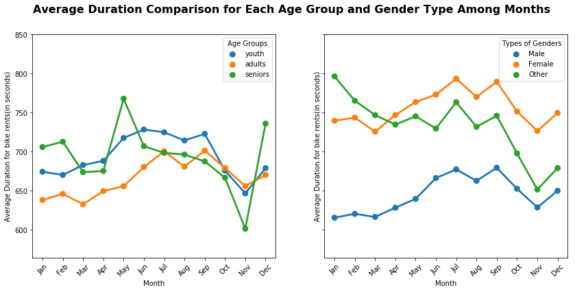

```python
# Plot 2 multivariate plots side by side
figure, axis = plt.subplots(ncols = 2, sharey = True, figsize = (14, 6))

sb.pointplot(data = cat_time_data, x = 'month', y = 'duration_sec', hue = 'age_group', linestyles = '-', errwidth = 0, ax = axis[0])
plt.sca(axis[0])
plt.xticks(rotation = 45)
plt.xlabel('Month')
plt.ylabel('Average Duration for bike rents(in seconds)')
plt.legend(title='Age Groups')

sb.pointplot(data = cat_time_data, x = 'month', y = 'duration_sec', hue = 'member_gender', linestyles = '-', errwidth = 0, ax = axis[1])
plt.sca(axis[1])
plt.xticks(rotation = 45)
plt.xlabel('Month')
plt.ylabel('Average Duration for bike rents(in seconds)')
plt.legend(title='Types of Genders')

plt.suptitle('Average Duration Comparison for Each Age Group and Gender Type Among Months', fontsize = 16, fontweight = 'bold');
```

## Distribution of Bike Rent Duration for Each Gender Type Within Each Age Group

**Now, as we were interested in exploring the relationship between age groups and gender, let's explore this further by combining `member_gender` in the boxplot of `duration_sec` vs `age_group`.**

**Observations:**

**1. Among the youth, females are showing much variance for duration and the most common duration is also high than the males and others, while males and others are at the same level of most common duration**

**2. Adults show the same trend as youth among males, females and others.**

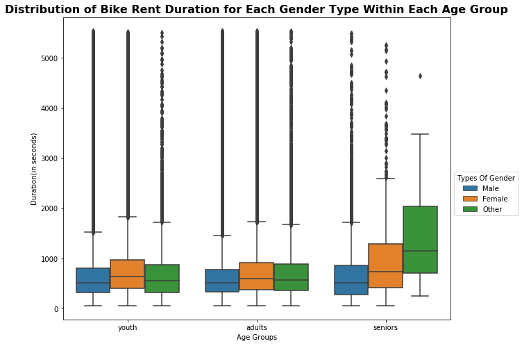

```python
plt.figure(figsize = (10, 8))
sb.boxplot(data = lim_df, x = 'age_group', y = 'duration_sec', hue = 'member_gender')
plt.legend(loc = 0, bbox_to_anchor = (1, 0.5), title = 'Types Of Gender')
plt.xlabel('Age Groups')
plt.ylabel('Duration(in seconds)')
plt.title('Distribution of Bike Rent Duration for Each Gender Type Within Each Age Group', fontsize = 16, fontweight = 'bold')
```